# NY real estate

Amin Shirazi

4/8/2021

```r
train<- read.csv('./data/Queens Training Set.csv') %>% select(- X)

names(train)
```

```
##  [1] "BOROUGH"                        "NEIGHBORHOOD"
##  [3] "BUILDING.CLASS.CATEGORY"        "TAX.CLASS.AT.PRESENT"
##  [5] "BLOCK"                          "LOT"
##  [7] "EASE.MENT"                      "BUILDING.CLASS.AT.PRESENT"
##  [9] "ADDRESS"                        "APARTMENT.NUMBER"
## [11] "ZIP.CODE"                       "RESIDENTIAL.UNITS"
## [13] "COMMERCIAL.UNITS"               "TOTAL.UNITS"
## [15] "LAND.SQUARE.FEET"               "GROSS.SQUARE.FEET"
## [17] "YEAR.BUILT"                     "TAX.CLASS.AT.TIME.OF.SALE"
## [19] "BUILDING.CLASS.AT.TIME.OF.SALE" "SALE.PRICE"
## [21] "SALE.DATE"
```

```r
dim(train)
```

```
## [1] 57382    21
```

- **BOROUGH** is all equal to 4
- Here is the list of **neighborhood**. Probably we can use the online data to sort the neighborhood w.r.t the price. It makes sense to have higher price for houses in some neighborhood.

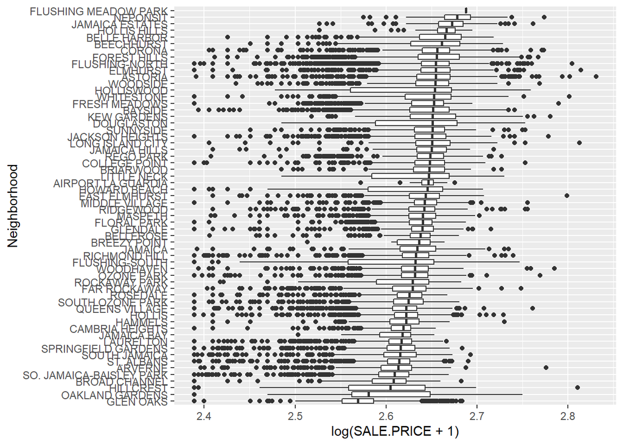

```r
train %>% mutate(NEIGHBORHOOD = as.factor(NEIGHBORHOOD),
                 SALE.PRICE = log(SALE.PRICE+1)) %>%
  ggplot(aes(reorder(NEIGHBORHOOD, SALE.PRICE, FUN = median), log(SALE.PRICE+1))) +
  geom_boxplot() + coord_flip() + xlab('Neighborhood')
```

- **Building class category**

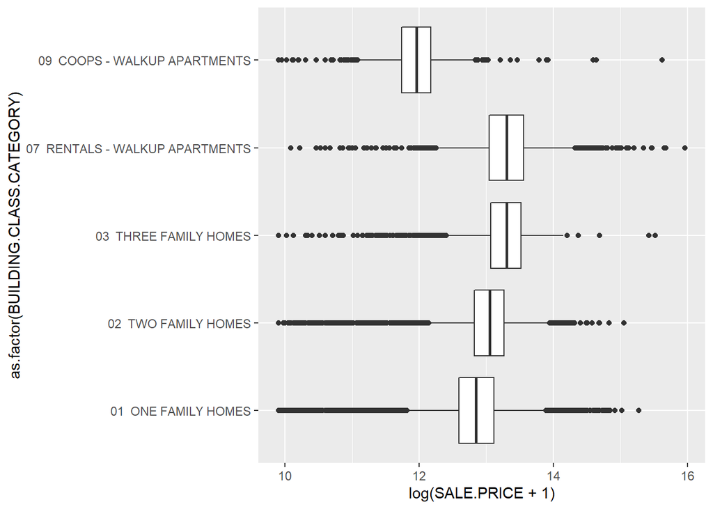

```r
train %>% ggplot(aes(as.factor(BUILDING.CLASS.CATEGORY), log(SALE.PRICE+1))) + geom_boxplot() +
  coord_flip()
```

- **Tax class at the present**

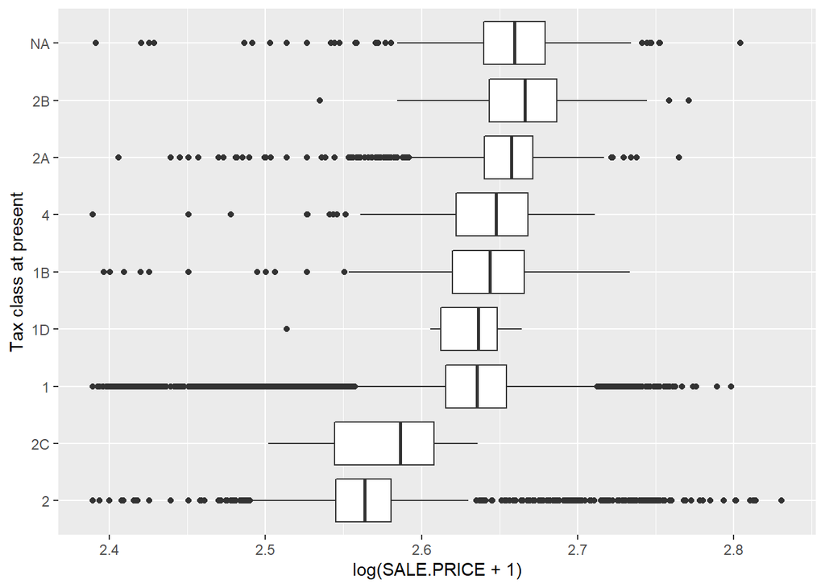

```r
train %>% mutate(TAX.CLASS.AT.PRESENT = as.factor(TAX.CLASS.AT.PRESENT),
                 SALE.PRICE = log(SALE.PRICE+1)) %>%
  ggplot(aes(reorder(TAX.CLASS.AT.PRESENT, SALE.PRICE, FUN = median), log(SALE.PRICE+1))) +
  geom_boxplot() + coord_flip() + xlab('Tax class at present')
```

- for the **Block**, there are 9551 different categories in the data. Idk how to get them to work. We might be able to cluster the price w.r.t the blocks.
- Similarly for **LOT** 567 unique categories
- **Easement** could be removed from the data. It is all NA
- **BUILDING.CLASS.AT.PRESENT**

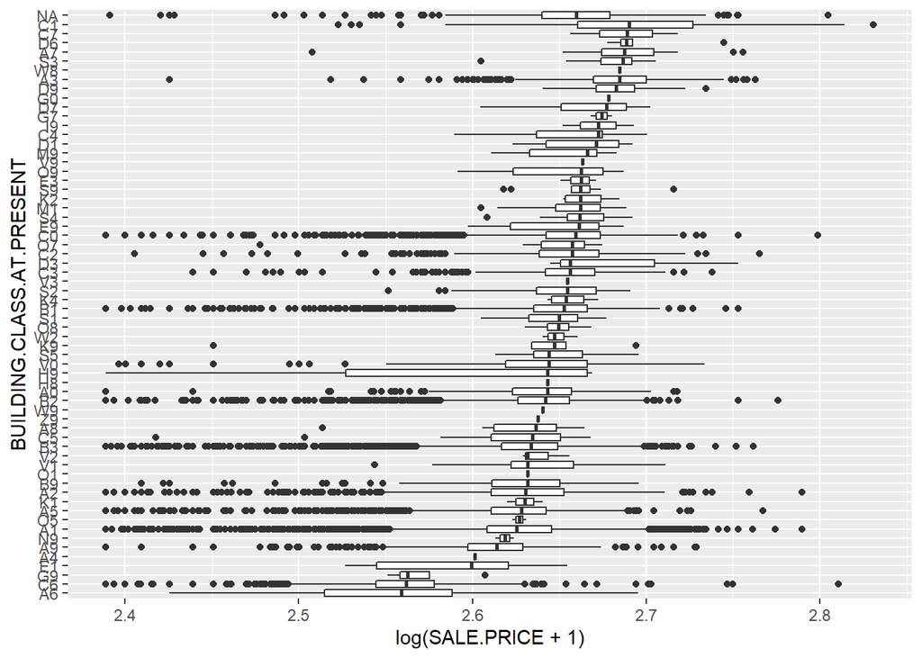

```r
train %>% mutate(BUILDING.CLASS.AT.PRESENT = as.factor(BUILDING.CLASS.AT.PRESENT),
                 SALE.PRICE = log(SALE.PRICE+1)) %>%
  ggplot(aes(reorder(BUILDING.CLASS.AT.PRESENT, SALE.PRICE, FUN = median), log(SALE.PRICE+1))) +
  geom_boxplot() + coord_flip() + xlab('BUILDING.CLASS.AT.PRESENT')
```

- For **Address**, currently no use of this variable, but we may use that for clustering or for making new features.
- **Apartment number** should also be removed from the data. They are almost all NA’s
- **Zip code** again can be used for clustering the data or for creating new features.
- **RESIDENTIAL.UNITS**: Since the aim is to predict house price, maybe we can filter out the observations with zero residential units. Maybe! What does it mean to have no residential units? Are we going to predict price for houses only or for buildings and houses?

```r
train$RESIDENTIAL.UNITS %>% table()
```

```
## .
##     0     1     2     3     4     5     6     7     8     9    10    11    12
##  5181 25524 20647  4282   717   125   473    57    86    16    13    10    24
##    13    14    15    16    17    18    19    20    21    22    23    24    25
##     3    12     5    39     3     4     6    11     3     6     3    16     3
##    26    27    28    29    32    33    34    35    36    37    38    39    40
##     3     8     1     3     3     1     1     2     2     1     1     1     5
##    42    45    48    50    56    58    60    66    68    73    80   100   108
##     2     4     1     1     1     1     1     1     2     1     1     2     2
##   126   128   132   136   140   144   148   152   156   168   172   176   180
##     1     1     1     1     1     1     1     3     1     6     2     2     2
##   181   188   192   194   198   200   210   212   244   248   266   280   312
##     1     4     3     2     1     3     3     1     2     1     1     5     1
##   350   685  1885
##     1     3     6
```

The box plot:

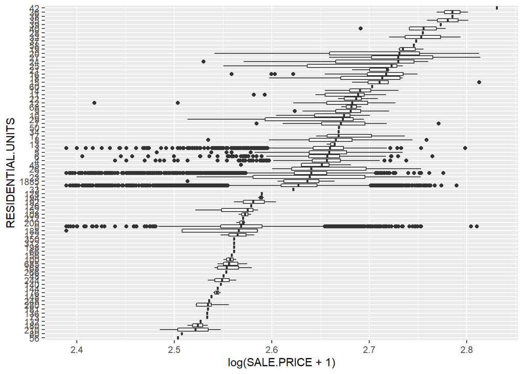

```r
train %>% mutate(RESIDENTIAL.UNITS = as.factor(RESIDENTIAL.UNITS),
                 SALE.PRICE = log(SALE.PRICE+1)) %>%
  ggplot(aes(reorder(RESIDENTIAL.UNITS, SALE.PRICE, FUN = median), log(SALE.PRICE+1))) +
  geom_boxplot() + coord_flip() + xlab('RESIDENTIAL.UNITS')
```

- **Commercial units**: there are 75 observations with zero residential units and at least one commercial units. Interestingly, there are 5106 observations with neither any residential units nor commercial. Needs to dig in to understand what they are
- If the aim is to predict price for any type of property (commercial or residential or both), we may consider **Total Units**. There are two cases where the total units is not equal to the sum of commercial and residential units. Those are:

```r
d.tot.unit <- train %>% mutate(tot = COMMERCIAL.UNITS + RESIDENTIAL.UNITS,
                 tot.true = ifelse(tot == TOTAL.UNITS, 1, 0))
d.tot.unit %>% filter(tot.true ==0)
```

| BOROUGH | NEIGHBORHOOD | BUILDING.CLASS.CATEGORY | TAX.CLASS.AT.PRESENT | BLOCK | LOT | EASE.MENT | BUILDING.CLASS.AT.PRESENT | ADDRESS | APARTMENT.NUMBER | ZIP.CODE | RESIDENTIAL.UNITS | COMMERCIAL.UNITS | TOTAL.UNITS | LAND.SQUARE.FEET | GROSS.SQUARE.FEET | YEAR.BUILT | TAX.CLASS.AT.TIME.OF.SALE | BUILDING.CLASS.AT.TIME.OF.SALE | SALE.PRICE | SALE.DATE | tot | tot.true |
| --- | --- | --- | --- | --- | --- | --- | --- | --- | --- | --- | --- | --- | --- | --- | --- | --- | --- | --- | --- | --- | --- | --- |
| 4 | JAMAICA | 03 THREE FAMILY HOMES | 1 | 9767 | 16 | NA | C0 | 88-33 161 STREET | NA | 11432 | 3 | 1 | 3 | 1940 | 3584 | 1910 | 1 | C0 | 499000 | 2004-07-29 | 4 | 0 |
| 4 | FLUSHING-NORTH | 01 ONE FAMILY HOMES | 4 | 5194 | 69 | NA | M9 | 43-64 BOWNE STREET | NA | 11355 | 1 | 1 | 1 | 2375 | 1116 | 1920 | 1 | A1 | 450000 | 2005-09-15 | 2 | 0 |

- **LAND.SQUARE.FEET**: Some unusual large land square feet value. There is definitely something wrong with them. We should think more and probably remove them from the data set. We can also look at the test set to see if there exists any unusual entry like this.

```r
train %>% arrange(desc(LAND.SQUARE.FEET)) %>% select(NEIGHBORHOOD, BUILDING.CLASS.CATEGORY,
                                                     TAX.CLASS.AT.PRESENT, BLOCK, ADDRESS,
                                                     ZIP.CODE, TOTAL.UNITS, LAND.SQUARE.FEET,
                                                     GROSS.SQUARE.FEET, SALE.PRICE) %>% head(15)
```

|  | NEIGHBORHOOD | BUILDING.CLASS.CATEGORY | TAX.CLASS.AT.PRESENT | BLOCK | ADDRESS | ZIP.CODE | TOTAL.UNITS | LAND.SQUARE.FEET | GROSS.SQUARE.FEET | SALE.PRICE |
| --- | --- | --- | --- | --- | --- | --- | --- | --- | --- | --- |
| 1 | BREEZY POINT | 01 ONE FAMILY HOMES | 1D | 16350 | 10 DEVON WALK | 11697 | 1904 | 12253428 | 200 | 450000 |
| 2 | BREEZY POINT | 01 ONE FAMILY HOMES | 1D | 16350 | 105 BEACH 217TH STREET | 11697 | 1904 | 12253428 | 200 | 635000 |
| 3 | BREEZY POINT | 01 ONE FAMILY HOMES | 1D | 16350 | 12 BEACH 220TH STREET | 11697 | 1904 | 12253428 | 200 | 525000 |
| 4 | BREEZY POINT | 01 ONE FAMILY HOMES | 1D | 16350 | 24 SUFFOLK WALK | 11697 | 1904 | 12253428 | 200 | 405000 |
| 5 | BREEZY POINT | 01 ONE FAMILY HOMES | 1D | 16350 | 217-02 BREEZY POINT BLVD | 11697 | 1904 | 12253428 | 200 | 280000 |
| 6 | BREEZY POINT | 01 ONE FAMILY HOMES | 1D | 16350 | 20 NEWPORT WALK | 11697 | 1904 | 12253428 | 200 | 85000 |
| 7 | HILLCREST | 09 COOPS - WALKUP APARTMENTS | 2 | 6715 | 8126 150 STREET | 11435 | 685 | 1584225 | 704500 | 145000 |
| 8 | HILLCREST | 09 COOPS - WALKUP APARTMENTS | 2 | 6715 | 147-23A CHARTER ROAD | 11435 | 685 | 1584225 | 704500 | 185000 |
| 9 | HILLCREST | 09 COOPS - WALKUP APARTMENTS | 2 | 6715 | 150-47 GRAND CENTRAL PARKWA | 11435 | 685 | 1584225 | 704500 | 125000 |
| 10 | QUEENS VILLAGE | 09 COOPS - WALKUP APARTMENTS | 2 | 7914 | 221-33 MANOR ROAD | 11427 | 350 | 694000 | 489600 | 155000 |

[output cut: 5 more lines]

There are also 4883 observations with zero land square feet.

```r
train %>% filter(LAND.SQUARE.FEET==0) %>% head()
```

|  | BOROUGH | NEIGHBORHOOD | BUILDING.CLASS.CATEGORY | TAX.CLASS.AT.PRESENT | BLOCK | LOT | EASE.MENT | BUILDING.CLASS.AT.PRESENT | ADDRESS | APARTMENT.NUMBER | ZIP.CODE | RESIDENTIAL.UNITS | COMMERCIAL.UNITS | TOTAL.UNITS | LAND.SQUARE.FEET | GROSS.SQUARE.FEET | YEAR.BUILT | TAX.CLASS.AT.TIME.OF.SALE | BUILDING.CLASS.AT.TIME.OF.SALE | SALE.PRICE | SALE.DATE |
| --- | --- | --- | --- | --- | --- | --- | --- | --- | --- | --- | --- | --- | --- | --- | --- | --- | --- | --- | --- | --- | --- |
| 1 | 4 | WHITESTONE | 09 COOPS - WALKUP APARTMENTS | 2 | 4744 | 28 | NA | C6 | 1616 160TH STREET,APT#6-9I | NA | 11357 | 0 | 0 | 0 | 0 | 0 | 1951 | 2 | C6 | 170000 | 2003-01-02 |
| 2 | 4 | OAKLAND GARDENS | 09 COOPS - WALKUP APARTMENTS | 2 | 7632 | 2 | NA | C6 | 68-91 218TH ST. | NA | 11364 | 0 | 0 | 0 | 0 | 0 | 1949 | 2 | C6 | 148000 | 2003-01-02 |
| 3 | 4 | HILLCREST | 09 COOPS - WALKUP APARTMENTS | 2 | 6715 | 2 | NA | C6 | 150-37 VILLAGE RD, APT 4C | NA | 11435 | 0 | 0 | 0 | 0 | 0 | 1947 | 2 | C6 | 135000 | 2003-01-02 |
| 4 | 4 | WHITESTONE | 09 COOPS - WALKUP APARTMENTS | 2 | 5740 | 139 | NA | C6 | 163-82 17TH AVE, APT 4-110 | NA | 11357 | 0 | 0 | 0 | 0 | 0 | 1951 | 2 | C6 | 177000 | 2003-01-03 |
| 5 | 4 | FLUSHING-NORTH | 09 COOPS - WALKUP APARTMENTS | 2 | 5325 | 65 | NA | C6 | 195-26A, 39TH AVE | NA | 11358 | 0 | 0 | 0 | 0 | 0 | 1950 | 2 | C6 | 151048 | 2003-01-03 |
| 6 | 4 | CORONA | 02 TWO FAMILY HOMES | NA | 1741 | 31 | NA | NA | 37 AVENUE | NA | 11368 | 0 | 0 | 0 | 0 | 0 | 0 | 1 | B2 | 629900 | 2003-01-06 |

- Hist on the log of land square feet

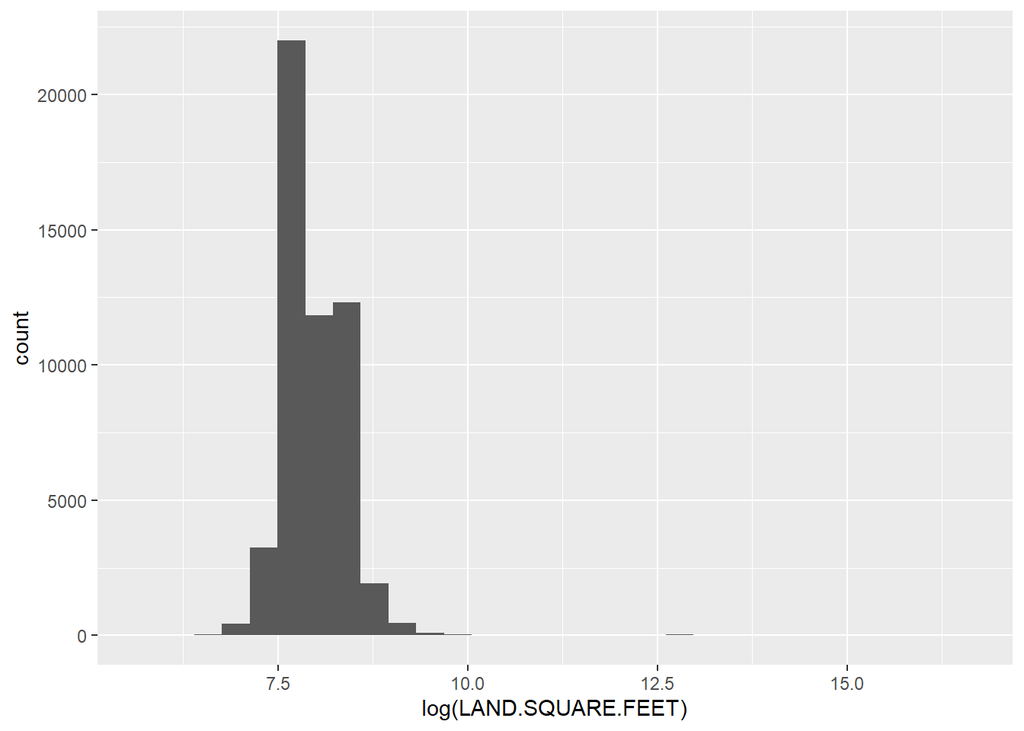

```r
train %>% filter(LAND.SQUARE.FEET>0) %>%  ggplot(aes(log(LAND.SQUARE.FEET))) + geom_histogram()
```

- Similarly, for **GROSS.SQUARE.FEET** we have 5132 zero values.

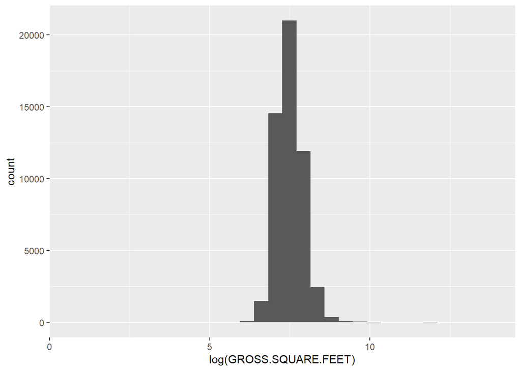

```r
# train %>% filter(GROSS.SQUARE.FEET==0)

train %>% filter(GROSS.SQUARE.FEET>0) %>%  ggplot(aes(log(GROSS.SQUARE.FEET))) + geom_histogram()
```

- My intuition is that we should use the log of Land and gross square feet on the first place, and clean the data on the second. The data is really noisy w.r.t different features, and before any analysis, we should clean the data.
- Not sure how we can use the info about **Year Built** and **Sale date**.
- Also, about **TAX.CLASS.AT.TIME.OF.SALE** and **BUILDING.CLASS.AT.TIME.OF.SALE**. Actually, have no idea if they are important in predicting house price.